# 基于信用卡数据算法对比

### 5.5.2层次稀疏聚类

```r
#稀疏层次聚类的调优参数选择
perm.out <- HierarchicalSparseCluster.permute(as.matrix(taiwan_num), wbounds=c(1.5,2:6),nperms=10)
```

```
## Running sparse hierarchical clustering on unpermuted data
## 123456
## Running sparse hierarchical clustering on permuted data
## Permutation  1  of  10
## 123456
## Permutation  2  of  10
## 123456
## Permutation  3  of  10
## 123456
## Permutation  4  of  10
## 123456
## Permutation  5  of  10
## 123456
## Permutation  6  of  10
## 123456
## Permutation  7  of  10
## 123456
## Permutation  8  of  10
## 123456
## Permutation  9  of  10
## 123456
## Permutation  10  of  10
## 123456
```

```r
print(perm.out)
```

```
## Tuning parameter selection results for Sparse Hierarchical Clustering:
##   Wbound # Non-Zero W's Gap Statistic Standard Deviation
## 1    1.5              5        0.0164              5e-04
## 2    2.0              7        0.0564              5e-04
## 3    3.0             14        0.1203              4e-04
## 4    4.0             20        0.1479              4e-04
## 5    5.0             20        0.1479              4e-04
## 6    6.0             20        0.1479              4e-04
## Tuning parameter that leads to largest Gap statistic:  4
```

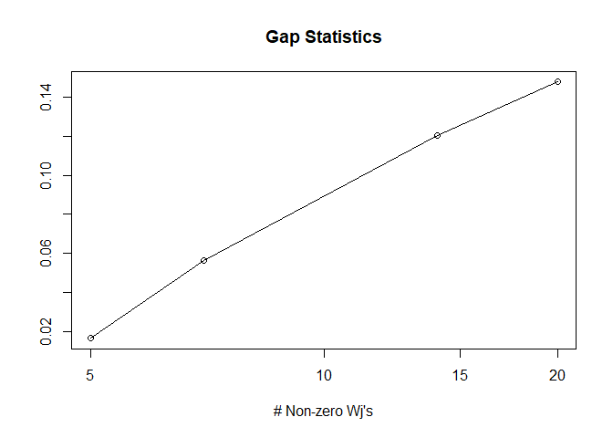

```r
plot(perm.out)
```

```r
# 执行稀疏层次聚类
sparsehc <- HierarchicalSparseCluster(dists=perm.out$dists,
                                      wbound=perm.out$bestw, method="complete")
```

```
## 12345678910
```

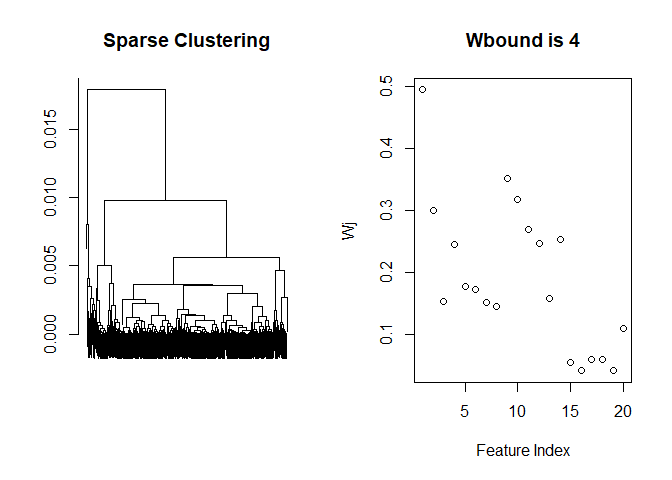

```r
par(mfrow=c(1,2))
plot(sparsehc)
```

```r
plot(sparsehc$hc)
print(sparsehc)
```

```
## Wbound is  4 :
## Number of non-zero weights:  20
## Sum of weights:  3.81629
```

```r
cutree(sparsehc$hc,2)
```

```
##   1   2   3   4   5   6   7   8   9  10  11  12  13  14  15  16  17  18
##   1   1   1   1   1   1   1   1   1   1   1   1   1   1   1   1   1   2
##  19  20  21  22  23  24  25  26  27  28  29  30  31  32  33  34  35  36
##   1   1   1   1   1   1   1   1   1   1   1   1   1   1   1   2   1   1
##  37  38  39  40  41  42  43  44  45  46  47  48  49  50  51  52  53  54
##   1   1   1   1   1   1   1   1   1   2   1   1   1   1   1   1   1   1
##  55  56  57  58  59  60  61  62  63  64  65  66  67  68  69  70  71  72
##   1   1   1   1   1   1   1   1   1   1   1   1   1   1   1   1   1   1
##  73  74  75  76  77  78  79  80  81  82  83  84  85  86  87  88  89  90
##   1   1   1   2   1   1   1   1   1   1   1   1   1   1   1   1   1   1
##  91  92  93  94  95  96  97  98  99 100 101 102 103 104 105 106 107 108
##   1   1   1   2   1   1   1   1   1   1   1   1   1   1   1   1   1   1
## 109 110 111 112 113 114 115 116 117 118 119 120 121 122 123 124 125 126
##   1   1   1   1   1   1   1   1   1   2   1   1   1   1   1   1   1   1
## 127 128 129 130 131 132 133 134 135 136 137 138 139 140 141 142 143 144
```

[output cut: 41 more lines]

```r
myfun1(taiwan[s,]$default,cutree(sparsehc$hc,2))
```

```
##         b
## a        未违约 违约
##   未违约    366   16
##   违约      111    7
```

[figure not shown]

```r
# 使用类标签知识来比较真实类
#获得聚类的标签
par(mfrow=c(1,1))
```

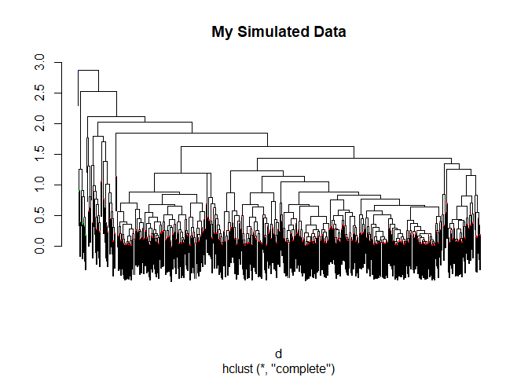

```r
y = cutree(hc, 3)
ColorDendrogram(hc,y=y,main="My Simulated Data",branchlength=.007)
```

```r
#现在，如果我们想看看数据是否包含了一个*二次聚类，
#在计算第一个得到的数据之后。我们寻找互补稀疏聚类：
# 重做分析，但这次使用“绝对值”不同：
perm.out <- HierarchicalSparseCluster.permute(as.matrix(taiwan_num),
                                              wbounds=c(1.5,2:6),
                                              nperms=5,
                                              dissimilarity="absolute.value")
```

```
## Running sparse hierarchical clustering on unpermuted data
## 123456
## Running sparse hierarchical clustering on permuted data
## Permutation  1  of  5
## 123456
## Permutation  2  of  5
## 123456
## Permutation  3  of  5
## 123456
## Permutation  4  of  5
## 123456
## Permutation  5  of  5
## 123456
```

```r
print(perm.out)
```

```
## Tuning parameter selection results for Sparse Hierarchical Clustering:
##   Wbound # Non-Zero W's Gap Statistic Standard Deviation
## 1    1.5              3        0.0037              2e-04
## 2    2.0              9        0.0138              1e-04
## 3    3.0             13        0.0420              1e-04
## 4    4.0             20        0.0677              1e-04
## 5    5.0             20        0.0677              1e-04
## 6    6.0             20        0.0677              1e-04
## Tuning parameter that leads to largest Gap statistic:  4
```

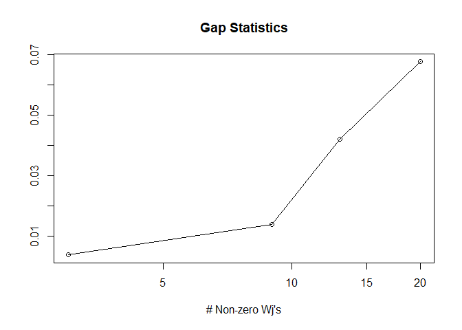

```r
plot(perm.out)
```

```r
# 执行稀疏层次聚类
sparsehc <- HierarchicalSparseCluster(dists=perm.out$dists, wbound=perm.out$bestw, method="complete", dissimilarity="absolute.value")
```

```
## 123456
```

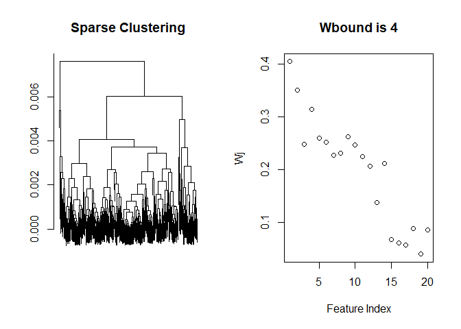

```r
par(mfrow=c(1,2))
plot(sparsehc)
```

## 5.6双向聚类

### 5.6.1数据预处理

```r
##双向聚类
##数据预处理,将分类变量处理成独热编码
library(caret)
taiwan=read.csv("card1.csv")
ohe_feats = c('SEX', 'EDUCATION', 'MARRIAGE')
taiwan$SEX<-as.factor(taiwan$SEX)
taiwan$EDUCATION<-as.factor(taiwan$EDUCATION)
taiwan$MARRIAGE<-as.factor(taiwan$MARRIAGE)
dummies <- dummyVars(~ SEX +  EDUCATION + MARRIAGE, data = taiwan)
df_all_ohe <- as.data.frame(predict(dummies, newdata = taiwan))
taiwan_bi <- cbind(df_all_ohe,taiwan_num)
```

### 5.6.2双向聚类分析

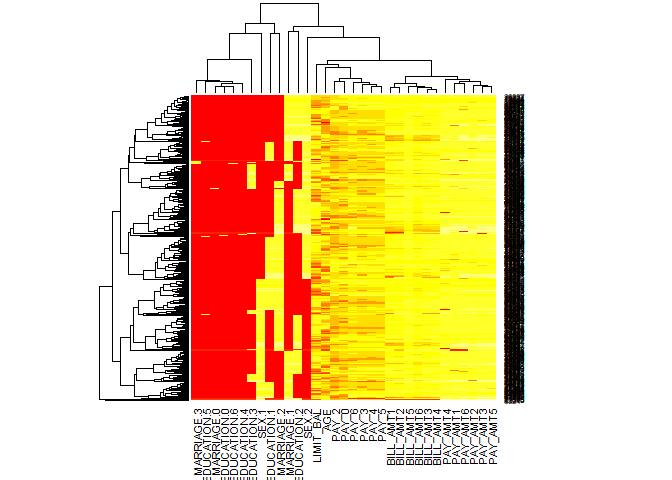

```r
library(biclust)
taiwan_bi=as.matrix(taiwan_bi[s,])
heatmap(taiwan_bi)
```

```r
bidata=binarize(taiwan_bi)                 #处理成二分数据
```

```
## [1] "Threshold:  0.5"
```

```r
bic<-biclust(bidata,method=BCBimax(),minr=400, minc=3)
bic #以BIMAX方法进行聚类
```

```
##
## An object of class Biclust
##
## call:
##  biclust(x = bidata, method = BCBimax(), minr = 400, minc = 3)
##
## Number of Clusters found:  100
##
## First  5  Cluster sizes:
##                    BC 1 BC 2 BC 3 BC 4 BC 5
## Number of Rows:     498  498  497  496  495
## Number of Columns:    3    3    4    4    5
```

[output not shown]

[output cut: 183 more lines]

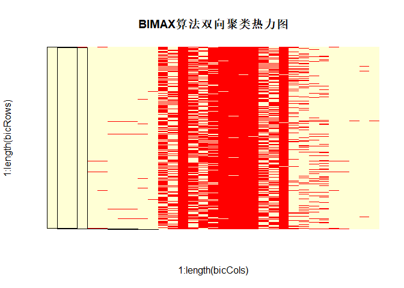

```r
heatmapBC(x = bidata,
          bicResult = bic,main="BIMAX算法双向聚类热力图")
```

```r
bic1<-biclust(bidata,method=BCCC(), number=2)
bic1 #以CC方法进行聚类
```

```
##
## An object of class Biclust
##
## call:
##  biclust(x = bidata, method = BCCC(), number = 2)
##
## There was one cluster found with
##   500 Rows and  33 columns
```

[figure not shown]

```r
##heatmapBC(bidata,bic1,main="CC算法双向聚类热力图")  #做出热力图
```

## 5.7聚类算法对比

在第五章中，基于台湾信贷数据进行了不同方式的聚类。不同的聚类方式对类别间的差异程度的衡量有所不同，层次聚类和k均值聚类是根据点与点之间的距离进行聚类的，衡量距离的定义有很多，本章中采用的都是欧氏距离。而Dbscan聚类是基于密度的，将密度大的区域作为一个类，而将密度小的区域作为类与类的边界。

在基于距离的聚类中，AGNES层次聚类是一种自下而上的一种层次能聚方法，不断地将点通过相似的距离进行融合，而k均值聚类则是通过给定的k个类，不断迭代，使规划目标类间距离最小，从而找到核心点，确定类别。

对于层次和k均值聚类，使用的都是数据的全部特征，这样做不但会增加计算量是计算效率降低，还会使得聚类效果不明显，忽略一些重要的变量，稀疏聚类的优势就是通过增加W权重，并对权重进行范数为1的限制，来对每一个特征指标在聚类中的表现进行限制。会突出一别变量的作用，在特征变量较多的状况的基因数据下，表现较好。起到数据压缩的效果。

双向聚类则是对观测和指标都进行聚类，以这种方式来反映一些变量在某些指标下的相似状况，而非全部特征下，因为能在全部指标下某些观测是不具有相似性的，所以更加具有实际意义。且尚香聚类的BIMAX在处理系数矩阵时具有独特的优势，在储存空间和运算时间上都较少。CC算法对BIMX的改进再在于，它弥补了在观测和指标较多是进行单列，但行的单节点删除的BIMAX法的运行效率较低，采用了大规模的多节点删除算法和节点添加算法，在大数据量下的表现会更加好。运行时间会进一步缩短。 最后，基于台湾信贷数据的聚类运算结果表如下表所示：

$~~~~~~~~~~~~~~~~~~~~~~~~~~~~~~~~~~~~~~~~~~~~~~~~~~~~~~~~~~~~~~$表1-2 信贷数据聚类算法比较表

|  | 准确率 | 运行时间（s） |
| --- | --- | --- |
| 层次聚类 | 76.2% | 0.25 |
| k-means聚类 | 66.2% | 0.85 |
| dbcan密度聚类 | 76.4% | 0.67 |
| k-means稀疏聚类 | 58.2% | 0.94 |
| 层次稀疏聚类 | 74.6% | 0.45 |

从对比表来看，基于台湾信贷数据上来看，在准确率上密度聚类的效果最好，而从运行时间上来看，层次聚类由于计算复杂小，所以耗费时间最短。

# 六、基于台湾信贷数据的分类算法的比较与分析

## 6.1 随机森林算法

随机森林是一种很灵活实用的方法，它有如下几个特点：

- 在当前所有算法中，具有极好的准确率
- 能够有效地运行在大数据集上
- 能够处理具有高维特征的输入样本，而且不需要降维
- 能够评估各个特征在分类问题上的重要性
- 在生成过程中，能够获取到内部生成误差的一种无偏估计
- 对于缺省值问题也能够获得很好得结果

### 6.1.1 随机森林数据预处理

```r
#数据预处理
alldata <- read.csv("D:/bigdatahw/算法/作业/card1.csv",head=TRUE,sep=',')
alldata$default.payment.next.month <- as.factor(alldata$default.payment.next.month)
alldata$SEX <- as.factor(alldata$SEX)
alldata$EDUCATION <- as.factor(alldata$EDUCATION)
alldata$MARRIAGE <- as.factor(alldata$MARRIAGE)
alldata$PAY_0 <- as.factor(alldata$PAY_0)
alldata$PAY_2 <- as.factor(alldata$PAY_2)
alldata$PAY_3 <- as.factor(alldata$PAY_3)
alldata$PAY_4 <- as.factor(alldata$PAY_4)
alldata$PAY_5 <- as.factor(alldata$PAY_5)
alldata$PAY_6 <- as.factor(alldata$PAY_6)
#切分训练集和测试集
n <- sample(1:nrow(alldata),0.8*nrow(alldata))
train <- alldata[n,-1]
test <- alldata[-n,-1]
```

### 6.1.2 随机森林实证检验

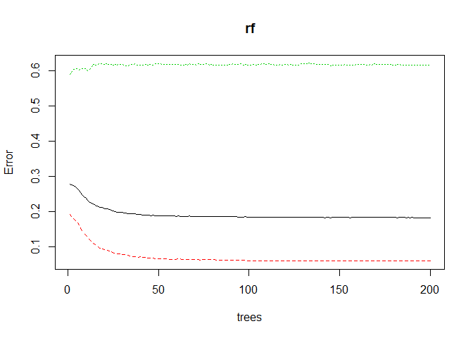

```r
rf <- randomForest(default.payment.next.month~.,data = train,
                   mtry=9,ntree=200,importance = T)
#查看训练集错误率随树的数量变化情况
plot(rf)
```

```r
#查看训练集平均错误率
mean(rf$err.rate)
```

```
## [1] 0.29328
```

```r
#训练集的混淆矩阵
rf$confusion
```

```
##       0    1 class.error
## 0 17563 1126  0.06024934
## 1  3271 2040  0.61589155
```

```r
#变量重要性
imp <- importance(x=rf)
imp
```

```
##                    0          1 MeanDecreaseAccuracy MeanDecreaseGini
## LIMIT_BAL 17.2029543  9.7047482            21.266565        475.47075
## SEX        0.5943296  1.7876208             1.380573         69.81759
## EDUCATION  4.3848673 -0.8927275             3.416634        155.05200
## MARRIAGE   8.5000092 -2.0870822             6.802100         81.16270
## AGE       16.7357291  2.1579620            15.888386        558.61180
## PAY_0     68.6409536 20.7379376            89.123802        980.54191
## PAY_2     24.3634091 -1.5713306            24.749841        387.41056
## PAY_3     22.3145536 -0.6133761            23.650806        224.12159
## PAY_4     25.7885982 -3.9628031            26.276405        137.14523
## PAY_5     18.7097157  4.9360715            22.120779        124.00833
## PAY_6     20.9214964  9.3434181            26.775247        116.52891
## BILL_AMT1 18.8808991 11.8397139            24.933455        519.15213
## BILL_AMT2 29.6618252 -6.7161920            32.357146        434.70636
## BILL_AMT3 27.7400577 -4.9780282            30.980817        400.06105
## BILL_AMT4 31.3560986 -8.6779579            34.183192        392.65935
## BILL_AMT5 25.4924452 -0.2068033            30.243083        390.36588
## BILL_AMT6 23.8797758  1.5465705            29.403866        402.75028
## PAY_AMT1  20.7704798 -4.2723432            22.589126        419.08704
## PAY_AMT2  19.5958596  2.8907808            22.421400        398.55678
## PAY_AMT3  21.8057086  6.1405462            26.279318        386.16816
## PAY_AMT4  17.6185767  5.4049239            22.768492        365.50157
## PAY_AMT5  22.1770788  0.2160371            26.252567        370.52992
## PAY_AMT6  25.1897353  4.5908928            26.634603        398.01621
```

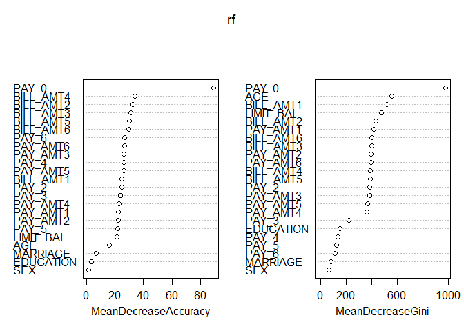

```r
varImpPlot(rf)
```

```r
#运行时间和消耗内存
#timecost <- system.time(randomForest(default.payment.next.month~.,
                                     #data = train,
                                     #mtry=9,ntree=500,
                                     #importance = T))
#print(timecost)
#定义评价函数
index2=function(table) {
  Accuracy=table[1,1]+table[2,2]
  #真阳性率+真阴性率=预测准确率
  precision=table[2,2]/sum(table[,2])
  #预测阳性率=精确度
  recall=table[2,2]/sum(table[2,])
  #第二类错误，灵敏度 =召回率
  F_measure=2*precision*recall/(precision+recall)
  #对前两者进行加权，综合结果
  results=data.frame(Accuracy=Accuracy,
                     recall=recall,
                     precision=precision,
                     F_measure=F_measure)
  return(results)
}
#测试集进行检验
pred1 <- predict(rf,test[,-25])
#测试集混淆矩阵
table(pred1,test$default.payment.next.month)
```

[output not shown]

```r
#测试集评价
rf.pred= predict(rf,newdata=test[,-25])
rf.real=test$default.payment.next.month
table_RF=table(rf.real,rf.pred)/nrow(test)
a=index2(table_RF)
print(a)
```

```
##    Accuracy    recall precision F_measure
## 1 0.8146667 0.3766038 0.6356688 0.4729858
```

```r
#ROC曲线
library(ROCR)
re.pred= predict(rf,newdata=test[,-25],type = "prob")
rocr = prediction(as.vector(re.pred[,2]),
                  test$default.payment.next.month)
AUC = performance(rocr,"auc")
print(AUC@y.values[[1]])
```

```
## [1] 0.7620552
```

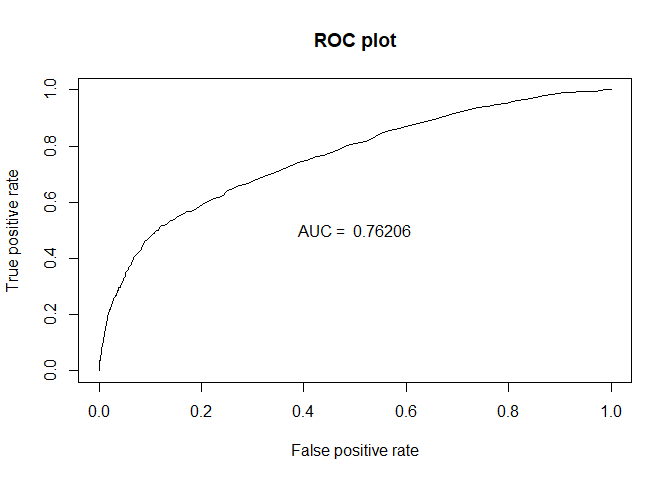

```r
ROC = performance(rocr,"tpr","fpr")
plot(ROC,main="ROC plot")
text(0.5,0.5,paste("AUC = ",
                   format(AUC@y.values[[1]],
                          digits=5,
                          scientific=FALSE)))
```

## 6.2 Adaboost集成算法

AdaBoost 采取加权多数表决的方法。 具体地，加大分类误差率小的弱分类器的权值，使其在表决中起较大的作用，减小 分类误差率大的弱分类器的权值，使其在表决中起较小的作用。

### 6.2.1 Adaboost数据预处理

```r
credit <- read.csv("D:/bigdatahw/算法/作业/card1.csv",head=TRUE,sep=',')
credit<-credit[,-1] #去除id行
names(credit)[24] <- 'label'
credit$label <- as.factor(credit$label)
credit$SEX <- as.factor(credit$SEX)
credit$EDUCATION <- as.factor(credit$EDUCATION)
credit$MARRIAGE <- as.factor(credit$MARRIAGE)
credit$PAY_0 <- as.factor(credit$PAY_0)
credit$PAY_2 <- as.factor(credit$PAY_2)
credit$PAY_3 <- as.factor(credit$PAY_3)
credit$PAY_4 <- as.factor(credit$PAY_4)
credit$PAY_5 <- as.factor(credit$PAY_5)
credit$PAY_6 <- as.factor(credit$PAY_6)

#按标签比例各20%筛选训练集与测试集
idx0 <- which(credit$label == 1)
idx1 <- which(credit$label == 0)

cls0 <- sample(idx0,round(0.2 * length(idx0)))
cls1 <- sample(idx1,round(0.2 * length(idx1)))

tst <- credit[c(cls0,cls1),]
trn <- credit[-c(cls0,cls1),]

#查看各数据矩阵维度
dim(credit)
```

```
## [1] 30000    24
```

```r
dim(tst)
```

```
## [1] 6000   24
```

```r
dim(trn)
```

```
## [1] 24000    24
```

### 6.2.2 Adaboost实证检验

```r
now <- Sys.time()
mem_change(model.AdaBoost <- boosting(label~.,data = trn))
```

```
## 48.4 MB
```

```r
Sys.time() - now
```

```
## Time difference of 6.846082 mins
```

```r
model.pred <- predict(model.AdaBoost,newdata = tst,type='class')
model.pred$confusion      #查看混淆矩阵
```

```
##                Observed Class
## Predicted Class    0    1
##               0 4454  844
##               1  219  483
```

```r
cal=function(table) {
  Accuracy=table[1,1]+table[2,2]
  #真阳性率+真阴性率=预测准确率
  precision=table[2,2]/sum(table[,2])
  #预测阳性率=精确度
  recall=table[2,2]/sum(table[2,])
  #第二类错误，灵敏度 =召回率
  F_measure=2*precision*recall/(precision+recall)
  #对前两者进行加权，综合结果
  results=data.frame(Accuracy=Accuracy,recall=recall,precision=precision,F_measure=F_measure)
  return(results)
}
cal(model.pred$confusion / 6000)
```

```
##    Accuracy    recall precision F_measure
## 1 0.8228333 0.6880342 0.3639789 0.4760966
```

## 6.3 XGBoost集成算法

XGBoost 算法总结起来大致其有三个优点：高效、准确度、模型的交互性：

- 正则化：标准 GBDT 提升树算法的实现没有像 XGBoost 这样的正则化 步骤。正则化用于控制模型的复杂度，对减少过拟合也是有帮助的。XGBoost 也正是以“正则化提升”技术而闻名。
- 并行处理：XGBoost 可以实现并行处理，相比 GBM 有了速度的飞跃。 不过，需要注意 XGBoost 的并行不是 tree 粒度的并行，XGBoost 也是一次迭 代完才能进行下一次迭代的（第 t 次迭代的代价函数里包含了前面 t-1 次迭代 的预测值）。XGBoost 的并行是在特征粒度上的。决策树的学习最耗时的一个 步骤就是对特征的值进行排序（因为要确定最佳分割点）。因此 XGBoost 在 R 重定义了一个自己数据矩阵类 DMatrix。XGBoost 在训练之前，预先对数据进 行了排序，然后保存为 block 结构，后面的迭代中重复利用索引地使用这个结 构，获得每个节点的梯度，大大减小计算量。这个 block 结构也使得并行成为 了可能，在进行节点的分裂时，需要计算每个特征的增益，最终选增益最大的 那个特征去做分裂，那么各个特征的增益计算就可以开多线程进行。
- 高度灵活性：XGBoost 允许用户定义自定义优化目标和评价标准，它 对模型增加了一个全新的维度，所以我们的处理不会受到任何限制。
- 缺失值处理：XGBoost 内置处理缺失值的规则。 用户需要提供一个 和其它样本不同的值，然后把它作为一个参数传进去，以此来作为缺失值的取 值。XGBoost 在不同节点遇到缺失值时采用不同的处理方法，并且会学习未来 遇到缺失值时的处理方法。
- 剪枝：当分裂时遇到一个负损失时，传统 GBDT 会停止分裂。因此传 统 GBDT 实际上是一个贪心算法。XGBoost 会一直分裂到指定的最大深度 (max_depth)，然后回过头来剪枝。如果某个节点之后不再有正值，它会去除 这个分裂。这种做法的优点，当一个负损失（如-2）后面有个正损失（如+10） 的时候，就显现出来了。GBM 会在-2 处停下来，因为它遇到了一个负值。但是 XGBoost 会继续分裂，然后发现这两个分裂综合起来会得到+8，因此会保留这 两个分裂。
- 内置交叉验证：XGBoost 允许在每一轮 boosting 迭代中使用交叉验 证。因此，可以方便地获得最优 boosting 迭代次数。而传统的 GBDT 使用网格 搜索，只能检测有限个值

### 6.3.1 XGBoost数据预处理

```r
#读取训练数据集与测试数据集
taiwan<- read.csv("D:/bigdatahw/算法/作业/card1.csv",head=TRUE,sep=',') #读取台湾信用数据
set.seed(1234)      #设置随机种子，可以重复实验结果
tra=sample(1:nrow(taiwan), round(0.8* nrow(taiwan)))  #抽取80%,24000个数据作为训练集
train=taiwan[tra,-1]
test=taiwan[-tra,-1]
#独热编码分类特征
ohe_feats = c('SEX', 'EDUCATION', 'MARRIAGE')
train$SEX<-as.factor(train$SEX)
train$EDUCATION<-as.factor(train$EDUCATION)
train$MARRIAGE<-as.factor(train$MARRIAGE)
dummies <- dummyVars(~ SEX +  EDUCATION + MARRIAGE, data = train)
df_all_ohe <- as.data.frame(predict(dummies, newdata = train))
train <- cbind(df_all_ohe,train[,-c(2,3,4)])

ohe_feats = c('SEX', 'EDUCATION', 'MARRIAGE')
test$SEX<-as.factor(test$SEX)
test$EDUCATION<-as.factor(test$EDUCATION)
test$MARRIAGE<-as.factor(test$MARRIAGE)
dummies <- dummyVars(~ SEX +  EDUCATION + MARRIAGE, data = test)
df_all_ohe <- as.data.frame(predict(dummies, newdata = test))
test<- cbind(df_all_ohe,test[,-c(2,3,4)])

#切分训练特征与回归特征
x<-train[,1:33]
y<-train[,34]
x<-apply(x,2,as.numeric)        #将x的列变量转化为数字型，xgboost对数据类型要求严格
y<-as.numeric(y)             #将y也转化为数字型变量
```